# Selection on within-individual variation in flowering time in Lathyrus vernus

Analyses of relationships between phenological traits and fruit initiation and pre-dispersal seed predation, and analyses of phenotypic selection on phenological traits

Alicia Valdés

30 March, 2023

```r
load(file="output/BCIs_sel_nfl_linear.RData")
load(file="output/BCIs_sel_nfl_nonlinear.RData")
load(file="output/BCIs_sel_nfl_linear_87.RData")
load(file="output/BCIs_sel_nfl_linear_88.RData")
load(file="output/BCIs_sel_nfl_linear_89.RData")
load(file="output/BCIs_sel_nfl_nonlinear_87.RData")
load(file="output/BCIs_sel_nfl_nonlinear_88.RData")
load(file="output/BCIs_sel_nfl_nonlinear_89.RData")
load(file="output/BCIs_sel_nfl_linear_87_mv.RData")
load(file="output/BCIs_sel_nfl_linear_88_mv.RData")
load(file="output/BCIs_sel_nfl_linear_89_mv.RData")
load(file="output/BCIs_sel_nfl_nonlinear_87_mv.RData")
load(file="output/BCIs_sel_nfl_nonlinear_88_mv.RData")
load(file="output/BCIs_sel_nfl_nonlinear_89_mv.RData")
load(file="output/BCIs_sel_nfl_linear_87_mv2.RData")
load(file="output/BCIs_sel_nfl_linear_88_mv2.RData")
load(file="output/BCIs_sel_nfl_linear_89_mv2.RData")
load(file="output/BCIs_sel_nfl_nonlinear_87_mv2.RData")
load(file="output/BCIs_sel_nfl_nonlinear_88_mv2.RData")
load(file="output/BCIs_sel_nfl_nonlinear_89_mv2.RData")
```

# Read clean data from .csv file

```r
data_ids <- read_csv("data/clean/data_ids.csv")
data_ids$imp_seed_preyed <- as.factor(data_ids$imp_seed_preyed)
data_ids$year <- as.factor(data_ids$year)
data_ids$subplot<-as.factor(data_ids$subplot)
data_id_flowers <- read_csv("data/clean/data_id_flowers.csv")
```

# Figure 1 (theoretical)

```r
# Changes in mean
mean_data<-data.frame(A_early=rnorm(500000,mean=63.2,sd=0.64),
                      B_medium=rnorm(500000,mean=66.2,sd=0.64),
                      C_late=rnorm(500000,mean=69.2,sd=0.64))%>%
  pivot_longer(cols=A_early:C_late,names_to="names",values_to="values")
summary_mean_data<-mean_data%>%
  group_by(names)%>%
  summarise(mean(values),var(values),skewness(values),kurtosis(values))
summary_mean_data
```

| names | mean(values) | var(values) | skewness(values) | kurtosis(values) |
| --- | --- | --- | --- | --- |
| A_early | 63.19819 | 0.4099097 | -0.003668676 | 2.998672 |
| B_medium | 66.19959 | 0.4107637 | 0.003897920 | 2.999809 |
| C_late | 69.20035 | 0.4098841 | 0.002366760 | 2.996296 |

```r
# Changes in variance
var_data<-data.frame(A_low=rnorm(500000,mean=66.2,sd=0.34),
                     B_medium=rnorm(500000,mean=66.2,sd=0.64),
                     C_large=rnorm(500000,mean=66.2,sd=0.94))%>%
  pivot_longer(cols=A_low:C_large,names_to="names",values_to="values")
summary_var_data<-var_data%>%
  group_by(names)%>%
  summarise(mean(values),var(values),skewness(values),kurtosis(values))
summary_var_data
```

| names | mean(values) | var(values) | skewness(values) | kurtosis(values) |
| --- | --- | --- | --- | --- |
| A_low | 66.20031 | 0.1155517 | -0.001803826 | 3.003276 |
| B_medium | 66.20091 | 0.4098493 | 0.001826350 | 3.005367 |
| C_large | 66.19980 | 0.8835669 | 0.005045265 | 2.998236 |

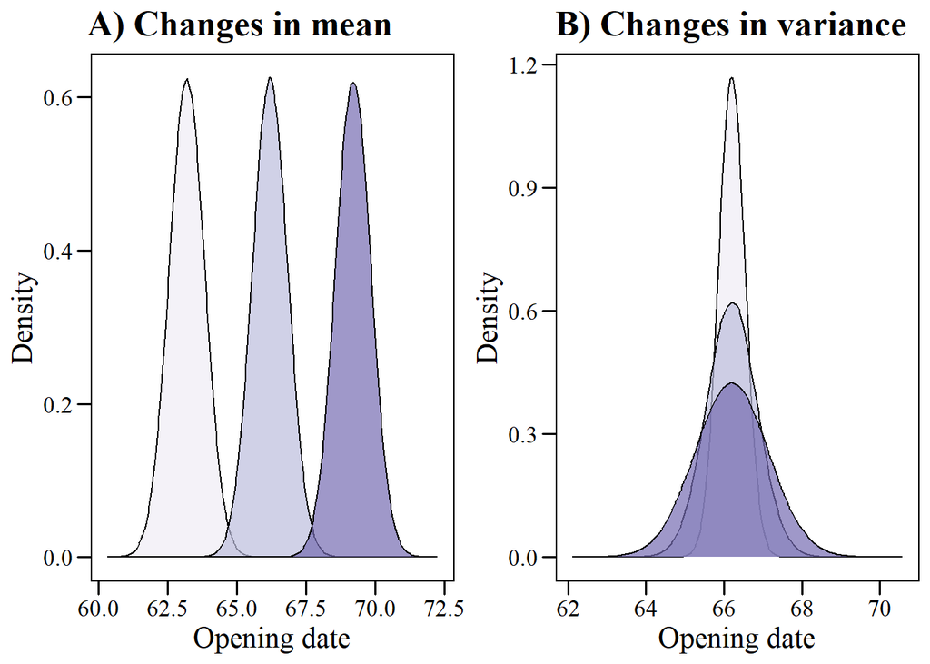

```r
# Changes in skewness and kurtosis --> modify in Inkscape
fig1_part<-grid.arrange(
  ggplot(mean_data,aes(x=values,fill=names))+
    geom_density(alpha=0.7)+
    xlab("Opening date")+
    ylab("Density")+my_theme()+ggtitle("A) Changes in mean")+
    scale_fill_manual(values=c("#efedf5","#bcbddc","#756bb1")),
  ggplot(var_data,aes(x=values,fill=names))+geom_density(alpha=0.7)+
    xlab("Opening date")+
    ylab("Density")+my_theme()+ggtitle("B) Changes in variance")+
    scale_fill_manual(values=c("#efedf5","#bcbddc","#756bb1")),
  ncol=2)
```

```r
ggsave(file="output/figures/fig1_part.svg", plot=fig1_part, width=10, height=4)
```

# Descriptive

## Flowering phenology curves of individuals

```r
ids_years_1_2fl<-data_id_flowers%>%group_by(year,id)%>%mutate(count=n())%>%
  filter(count==1|count==2)%>%select(id,year)%>%distinct(id,year)
# All ids and years with 1 or 2 fl

data_id_flowers_3fl<-data_id_flowers %>%
  anti_join(ids_years_1_2fl)%>% # Keep only ids and years with at least 3 fl
  mutate(subplot=factor(subplot,ordered=T),number=factor(number,ordered=T))%>%
  mutate(year=factor(year),
         id=factor(id,
                   levels=unique(id[order(subplot,number)]), ordered=TRUE))
# id as ordered factor based on subplot and number

# split the data into chunks of 21 subplot, number
# based on their unique id values
id_chunks <-data_id_flowers_3fl %>%
  distinct(subplot,number) %>%
  arrange(subplot,number)%>%
  mutate(chunk = ceiling(row_number()/21)) %>%
  inner_join(data_id_flowers_3fl, by =c("subplot","number")) %>%
  split(.$chunk)

# create a list of plots, one for each chunk of ids
plot_list<-map(id_chunks,~ggplot(.x,aes(x=opening_date_v,y=id,fill=year))+
                   geom_density_ridges()+
                   theme_ridges()+theme(text=element_text(family="serif"))+
                   theme(legend.position="top")+
                   labs(x="Opening date (number of days from the vernal equinox)",
                        y="Individual")+
                   scale_fill_manual(values=c("#E69F00","#56B4E9","#009E73")))

# save the plots as TIFF files
walk2(plot_list, seq_along(plot_list),
      ~ ggsave(paste0("output/figures/myplot_", .y, ".tiff"),
               plot = .x, width = 6.5, height = 9, units = "in", dpi = 300))
```

## Distributions of the four moments

### All years

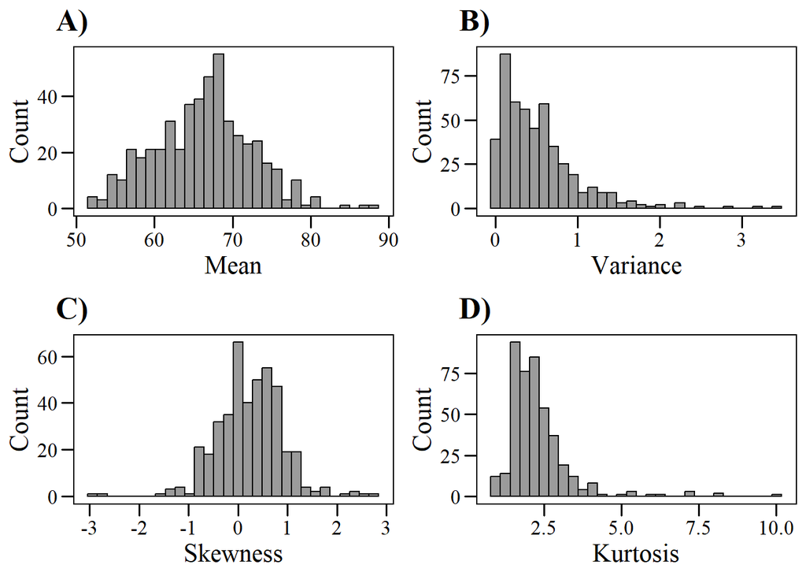

```r
histograms_SI<-grid.arrange(
  # Mean
  ggplot(data_ids,aes(x=avFD_v))+
    geom_histogram(color="black",alpha=0.6,position="identity")+
    ggtitle("A)")+
    my_theme()+xlab("Mean")+ylab("Count"),
  # Variance
  ggplot(data_ids,aes(x=var))+
    geom_histogram(color="black",alpha=0.6,position="identity")+
    ggtitle("B)")+
    my_theme()+xlab("Variance")+ylab("Count"),
  # Skewness
  ggplot(data_ids,aes(x=skew))+
    geom_histogram(color="black",alpha=0.6,position="identity")+
    ggtitle("C)")+
    my_theme()+xlab("Skewness")+ylab("Count"),
  # Kurtosis
  ggplot(data_ids,aes(x=kurt))+
    geom_histogram(color="black",alpha=0.6,position="identity")+
    ggtitle("D)")+
    my_theme()+xlab("Kurtosis")+ylab("Count"),
  ncol=2)
```

```r
ggsave(histograms_SI,filename="output/figures/histograms_SI.tiff",
       device="tiff",width=20,height=15,units="cm",dpi=300,compression="lzw")
```

### By year

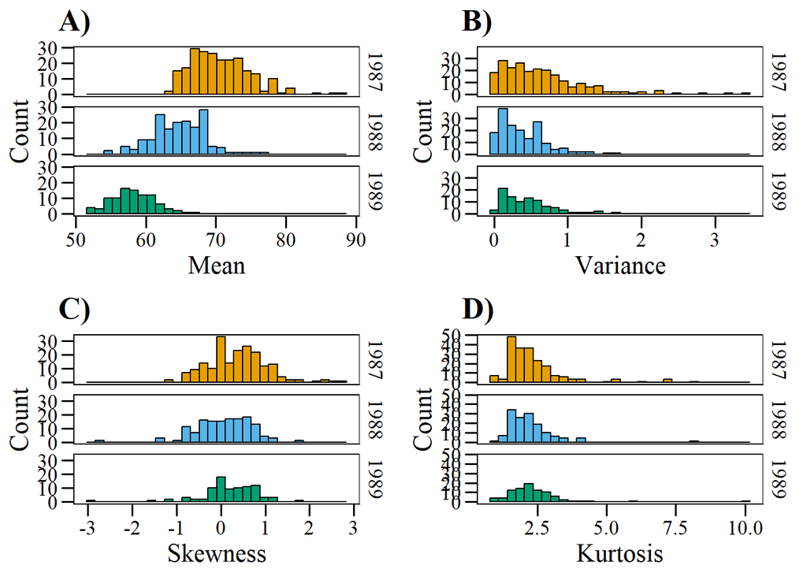

```r
histograms_SI_years<-grid.arrange(
  # Mean
  ggplot(data_ids,aes(x=avFD_v,fill=year))+
    geom_histogram(color="black",position="identity")+
    scale_fill_manual(values=c("#E69F00","#56B4E9","#009E73"))+
    facet_grid(rows=vars(year))+ggtitle("A)")+
    my_theme()+xlab("Mean")+ylab("Count"),
  # Variance
  ggplot(data_ids,aes(x=var,fill=year))+
    geom_histogram(color="black",position="identity")+
    scale_fill_manual(values=c("#E69F00","#56B4E9","#009E73"))+
    facet_grid(rows=vars(year))+ggtitle("B)")+
    my_theme()+xlab("Variance")+ylab("Count"),
  # Skewness
  ggplot(data_ids,aes(x=skew,fill=year))+
    geom_histogram(color="black",position="identity")+
    scale_fill_manual(values=c("#E69F00","#56B4E9","#009E73"))+
    facet_grid(rows=vars(year))+ggtitle("C)")+
    my_theme()+xlab("Skewness")+ylab("Count"),
  # Kurtosis
  ggplot(data_ids,aes(x=kurt,fill=year))+
    geom_histogram(color="black",position="identity")+
    scale_fill_manual(values=c("#E69F00","#56B4E9","#009E73"))+
    facet_grid(rows=vars(year))+ggtitle("D)")+
    my_theme()+xlab("Kurtosis")+ylab("Count"),
  ncol=2)
```

```r
ggsave(histograms_SI_years,filename="output/figures/histograms_SI_years.tiff",
       device="tiff",width=20,height=25,units="cm",dpi=300,compression="lzw")
```

## Ranges, means and SD

```r
data_ids%>%
  summarise(min_mean=min(avFD_v),max_mean=max(avFD_v),
            mean_mean=mean(avFD_v),sd_mean=sd(avFD_v),
            min_var=min(var,na.rm=T),max_var=max(var,na.rm=T),
            mean_var=mean(var,na.rm=T),sd_var=sd(var,na.rm=T),
            min_skew=min(skew,na.rm=T),max_skew=max(skew,na.rm=T),
            mean_skew=mean(skew,na.rm=T),sd_skew=sd(skew,na.rm=T),
            min_kurt=min(kurt,na.rm=T),max_kurt=max(kurt,na.rm=T),
            mean_kurt=mean(kurt,na.rm=T),sd_kurt=sd(kurt,na.rm=T))
```

| min_mean | max_mean | mean_mean | sd_mean | min_var | max_var | mean_var | sd_var | min_skew | max_skew | mean_skew | sd_skew | min_kurt | max_kurt | mean_kurt | sd_kurt |
| --- | --- | --- | --- | --- | --- | --- | --- | --- | --- | --- | --- | --- | --- | --- | --- |
| 51.62011 | 87.5962 | 66.21388 | 6.14252 | 0 | 3.421339 | 0.5196206 | 0.4760122 | -3.015113 | 2.666667 | 0.2345264 | 0.655765 | 1 | 10.09091 | 2.284744 | 1.017926 |

# Correlations

I will fit models using traits representing the 4 moments of the distribution (mean: avFD, variance: var, skewness: skew and kurtosis: kurt)

Check the correlations of these 4 traits using all data:

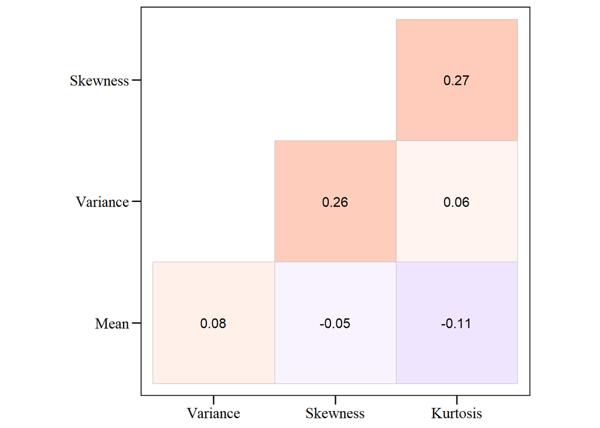

```r
data_ids%>%select(year,avFD_v,var,skew,kurt) %>%
  rename(Mean=avFD_v,Variance=var,Skewness=skew,Kurtosis=kurt)%>%
  select_if(is.numeric) %>%
  cor(use="pairwise.complete.obs") %>%
  ggcorrplot(method = "square", type = "lower", hc.order = F, lab = T)+
  theme(legend.position="none")+my_theme()+xlab(NULL)+ylab(NULL)
```

```r
ggsave(filename="output/figures/corr_SI.tiff",
       device="tiff",width=10,height=8,units="cm",dpi=300,compression="lzw")
```

Check the yearly correlations:

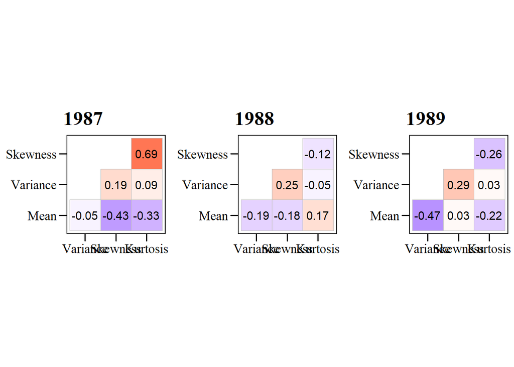

```r
corr_SI_years<-grid.arrange(
  data_ids%>%select(year,avFD_v,var,skew,kurt) %>%
    filter(year==1987) %>%
    rename(Mean=avFD_v,Variance=var,Skewness=skew,Kurtosis=kurt)%>%
    select_if(is.numeric) %>%
    cor(use="pairwise.complete.obs") %>%
    ggcorrplot(method = "square", type = "lower", hc.order = F, lab = T)+
    ggtitle("1987")+theme(legend.position="none")+
    my_theme()+xlab(NULL)+ylab(NULL),
  data_ids%>%select(year,avFD_v,var,skew,kurt) %>%
    filter(year==1988) %>%
    rename(Mean=avFD_v,Variance=var,Skewness=skew,Kurtosis=kurt)%>%
    select_if(is.numeric) %>%
    cor(use="pairwise.complete.obs") %>%
    ggcorrplot(method = "square", type = "lower", hc.order = F, lab = T)+
    ggtitle("1988")+theme(legend.position="none")+
    my_theme()+xlab(NULL)+ylab(NULL),
  data_ids%>%select(year,avFD_v,var,skew,kurt) %>%
    filter(year==1989) %>%
    rename(Mean=avFD_v,Variance=var,Skewness=skew,Kurtosis=kurt)%>%
    select_if(is.numeric) %>%
    cor(use="pairwise.complete.obs") %>%
    ggcorrplot(method = "square", type = "lower", hc.order = F, lab = T)+
    ggtitle("1989")+theme(legend.position="none")+
    my_theme()+xlab(NULL)+ylab(NULL),
  ncol=3)
```

```r
ggsave(corr_SI_years,filename="output/figures/corr_SI_years.tiff",
       device="tiff",width=25,height=10,units="cm",dpi=300,compression="lzw")
```

Probaly OK? Check VIFs of each model.

# Multivariate GLMs

## FRUIT INITIATION

Using (within-year) standardized traits.

### Global models

#### Linear effects

```r
fr_init_linear<-glm(cbind(fr=n_fr,nofr=n_fl-n_fr)~avFD_std+var_std+
                      skew_std+kurt_std+year+
                      # Include main effect of year here
                      # but not in selection models!
                      avFD_std:year+var_std:year+skew_std:year+kurt_std:year,
                    data_ids,family="binomial")
tab_model(fr_init_linear,
          transform=NULL,show.ci=F,show.se=T,show.stat=T,digits=3,
          dv.labels=c("Fruit initiation, linear effects"))
```

|  | Fruit initiation, linear effects |  |  |  |
| --- | --- | --- | --- | --- |
| Predictors | Log-Odds | std. Error | Statistic | p |
| (Intercept) | -1.691 | 0.075 | -22.499 | **<0.001** |
| avFD std | -0.047 | 0.089 | -0.531 | 0.596 |
| var std | 0.119 | 0.056 | 2.145 | **0.032** |
| skew std | 0.359 | 0.122 | 2.941 | **0.003** |
| kurt std | -0.199 | 0.095 | -2.097 | **0.036** |
| year 1988 | -0.224 | 0.112 | -2.002 | **0.045** |
| year 1989 | -0.188 | 0.118 | -1.593 | 0.111 |
| avFD std × year 1988 | -0.320 | 0.130 | -2.472 | **0.013** |
| avFD std × year 1989 | -0.319 | 0.131 | -2.442 | **0.015** |
| var std × year 1988 | -0.128 | 0.099 | -1.295 | 0.195 |
| var std × year 1989 | -0.032 | 0.096 | -0.334 | 0.739 |
| skew std × year 1988 | -0.307 | 0.147 | -2.088 | **0.037** |
| skew std × year 1989 | -0.045 | 0.161 | -0.282 | 0.778 |
| kurt std × year 1988 | 0.271 | 0.123 | 2.199 | **0.028** |
| kurt std × year 1989 | 0.253 | 0.141 | 1.787 | 0.074 |
| Observations | 428 |  |  |  |

```r
Anova(fr_init_linear) # Use type II (now) or III?
```

|  | LR Chisq | Df | Pr(>Chisq) |
| --- | --- | --- | --- |
| avFD_std | 22.5485780 | 1 | 2.048961e-06 |
| var_std | 4.0506121 | 1 | 4.415533e-02 |
| skew_std | 13.7620690 | 1 | 2.074835e-04 |
| kurt_std | 0.1644218 | 1 | 6.851177e-01 |
| year | 5.0664389 | 2 | 7.940298e-02 |
| avFD_std:year | 7.9515352 | 2 | 1.876489e-02 |
| var_std:year | 1.6941501 | 2 | 4.286669e-01 |
| skew_std:year | 6.2067954 | 2 | 4.489640e-02 |
| kurt_std:year | 5.3806284 | 2 | 6.785961e-02 |

```r
check_collinearity(glm(cbind(fr=n_fr,nofr=n_fl-n_fr)~avFD_std+var_std+
                         skew_std+kurt_std+year,
                       data_ids,family="binomial"))
```

| Term | VIF | VIF_CI_low | VIF_CI_high | SE_factor | Tolerance | Tolerance_CI_low | Tolerance_CI_high |
| --- | --- | --- | --- | --- | --- | --- | --- |
| avFD_std | 1.114604 | 1.042428 | 1.309560 | 1.055748 | 0.8971799 | 0.7636154 | 0.9592989 |
| var_std | 1.073905 | 1.017530 | 1.311569 | 1.036294 | 0.9311811 | 0.7624457 | 0.9827716 |
| skew_std | 1.486645 | 1.334245 | 1.708532 | 1.219280 | 0.6726556 | 0.5852979 | 0.7494874 |
| kurt_std | 1.403239 | 1.266265 | 1.610676 | 1.184584 | 0.7126369 | 0.6208574 | 0.7897239 |
| year | 1.034109 | 1.001874 | 1.620766 | 1.016912 | 0.9670160 | 0.6169921 | 0.9981293 |

According to Anova, differences among years in the effects of avFD and skew.

##### Plot predictions

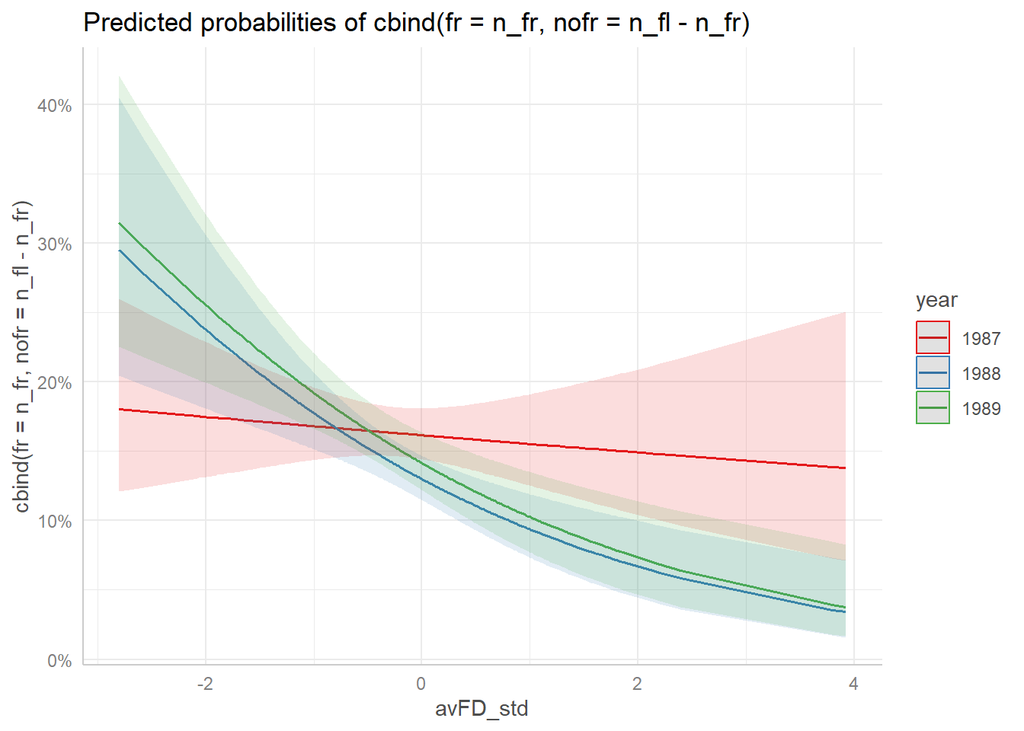

```r
plot(ggpredict(fr_init_linear,
               terms=c("avFD_std [all]","year"))) # Significant diffs among years
```

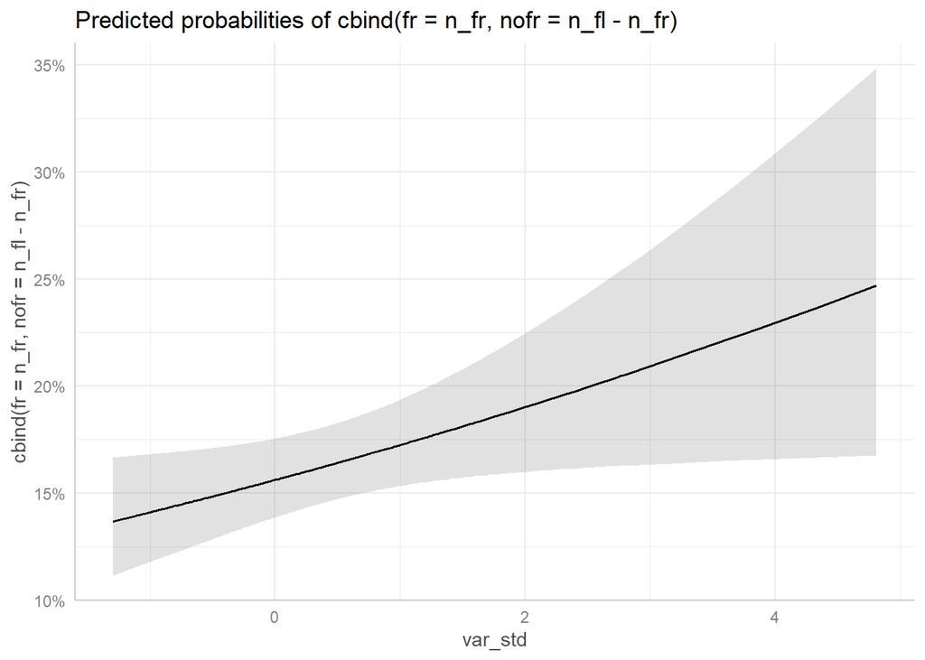

```r
plot(ggpredict(fr_init_linear,
               terms=c("var_std [all]"))) # Main effect signficant
```

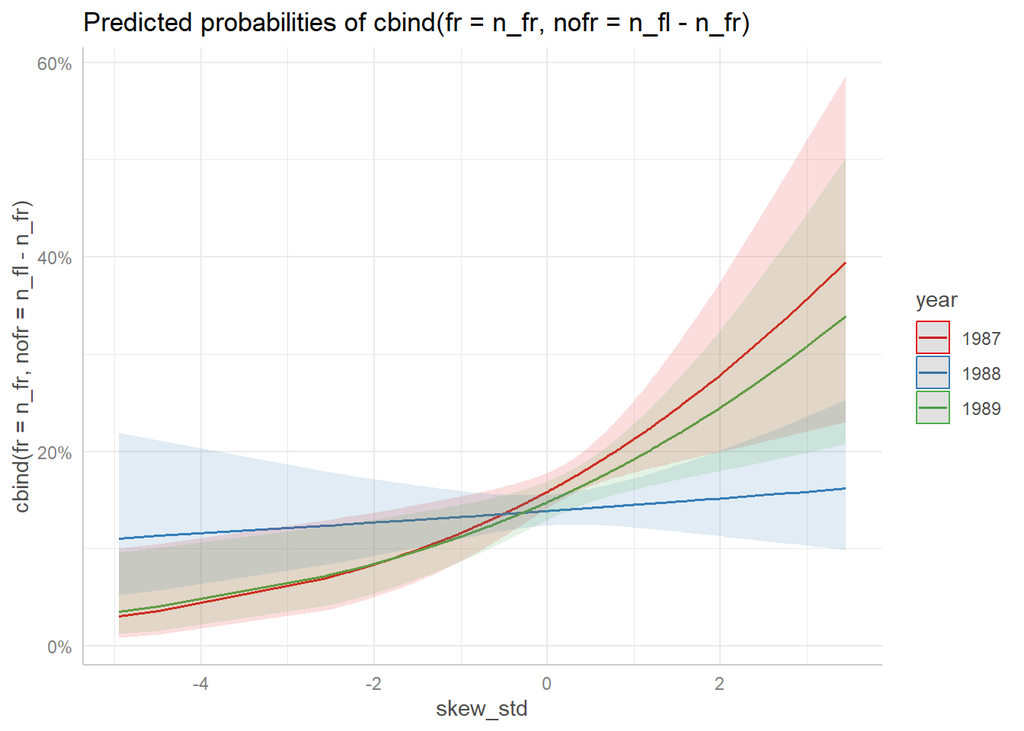

```r
plot(ggpredict(fr_init_linear,
               terms=c("skew_std [all]","year"))) # Significant diffs among years
```

#### Non-linear effects

```r
fr_init_nonlinear<-glm(cbind(fr=n_fr,nofr=n_fl-n_fr)~
                         avFD_std+var_std+skew_std+kurt_std+year+
                         avFD_std:year+var_std:year+skew_std:year+kurt_std:year+
                         I(avFD_std^2)+I(var_std^2)+I(skew_std^2)+I(kurt_std^2)+
                         I(avFD_std^2):year+I(var_std^2):year+
                         I(skew_std^2):year+I(kurt_std^2):year,
                       data_ids,family="binomial")
tab_model(fr_init_nonlinear,
          transform=NULL,show.ci=F,show.se=T,show.stat=T,digits=3,
          dv.labels=c("Fruit initiation, non linear effects"))
```

|  | Fruit initiation, non linear effects |  |  |  |
| --- | --- | --- | --- | --- |
| Predictors | Log-Odds | std. Error | Statistic | p |
| (Intercept) | -1.711 | 0.112 | -15.256 | **<0.001** |
| avFD std | -0.040 | 0.096 | -0.417 | 0.677 |
| var std | 0.045 | 0.112 | 0.404 | 0.686 |
| skew std | 0.394 | 0.123 | 3.210 | **0.001** |
| kurt std | -0.351 | 0.154 | -2.284 | **0.022** |
| year 1988 | -0.335 | 0.155 | -2.158 | **0.031** |
| year 1989 | -0.233 | 0.160 | -1.454 | 0.146 |
| avFD std^2 | -0.083 | 0.075 | -1.117 | 0.264 |
| var std^2 | 0.028 | 0.030 | 0.931 | 0.352 |
| skew std^2 | 0.103 | 0.089 | 1.158 | 0.247 |
| kurt std^2 | 0.006 | 0.041 | 0.137 | 0.891 |
| avFD std × year 1988 | -0.258 | 0.144 | -1.795 | 0.073 |
| avFD std × year 1989 | -0.291 | 0.163 | -1.787 | 0.074 |
| var std × year 1988 | -0.214 | 0.174 | -1.230 | 0.219 |
| var std × year 1989 | 0.128 | 0.180 | 0.713 | 0.476 |
| skew std × year 1988 | -0.322 | 0.150 | -2.152 | **0.031** |
| skew std × year 1989 | -0.042 | 0.172 | -0.245 | 0.807 |
| kurt std × year 1988 | 0.367 | 0.200 | 1.833 | 0.067 |
| kurt std × year 1989 | 0.312 | 0.243 | 1.282 | 0.200 |
| year 1988 × avFD std^2 | 0.178 | 0.110 | 1.610 | 0.107 |
| year 1989 × avFD std^2 | 0.138 | 0.117 | 1.181 | 0.238 |
| year 1988 × var std^2 | 0.085 | 0.061 | 1.396 | 0.163 |
| year 1989 × var std^2 | -0.074 | 0.067 | -1.117 | 0.264 |
| year 1988 × skew std^2 | -0.011 | 0.125 | -0.085 | 0.933 |
| year 1989 × skew std^2 | 0.030 | 0.161 | 0.184 | 0.854 |
| year 1988 × kurt std^2 | -0.031 | 0.054 | -0.572 | 0.567 |
| year 1989 × kurt std^2 | -0.056 | 0.082 | -0.675 | 0.500 |
| Observations | 428 |  |  |  |

```r
Anova(fr_init_nonlinear) # Use type II (now) or III?
```

|  | LR Chisq | Df | Pr(>Chisq) |
| --- | --- | --- | --- |
| avFD_std | 10.92254831 | 1 | 0.0009500084 |
| var_std | 0.05404246 | 1 | 0.8161727243 |
| skew_std | 13.40616707 | 1 | 0.0002507984 |
| kurt_std | 1.77217246 | 1 | 0.1831134479 |
| year | 3.33543033 | 2 | 0.1886776712 |
| I(avFD_std^2) | 0.00591973 | 1 | 0.9386714518 |
| I(var_std^2) | 1.74793915 | 1 | 0.1861360197 |
| I(skew_std^2) | 3.27648731 | 1 | 0.0702791976 |
| I(kurt_std^2) | 0.45592232 | 1 | 0.4995358736 |
| avFD_std:year | 4.62503872 | 2 | 0.0990114912 |

[output cut: 7 more lines]

None of the quadratic effects is significant.

Ratio of n observations to n parameters in the model:

```r
nobs(fr_init_nonlinear)/dim(model.matrix(fr_init_nonlinear))[2]
```

```
## [1] 15.85185
```

OK. If including interactions, it would be lower than 10. Similar problem with yearly models, so not including interactions in any model so far.

### Yearly models

#### Linear effects

```r
fr_init_linear_87<-glm(cbind(fr=n_fr,nofr=n_fl-n_fr)~
                         avFD_std+var_std+skew_std+kurt_std,
                       subset(data_ids,year==1987),family="binomial")
fr_init_linear_88<-glm(cbind(fr=n_fr,nofr=n_fl-n_fr)~
                         avFD_std+var_std+skew_std+kurt_std,
                    subset(data_ids,year==1988),family="binomial")
fr_init_linear_89<-glm(cbind(fr=n_fr,nofr=n_fl-n_fr)~
                         avFD_std+var_std+skew_std+kurt_std,
                    subset(data_ids,year==1989),family="binomial")
tab_model(fr_init_linear_87,fr_init_linear_88,fr_init_linear_89,
          transform=NULL,show.ci=F,show.se=T,show.stat=T,digits=3,
          dv.labels=c("1987","1988","1989"),
          title="Fruit initiation, linear effects")
```

Fruit initiation, linear effects

|  | 1987 |  |  |  | 1988 |  |  |  | 1989 |  |  |  |
| --- | --- | --- | --- | --- | --- | --- | --- | --- | --- | --- | --- | --- |
| Predictors | Log-Odds | std. Error | Statistic | p | Log-Odds | std. Error | Statistic | p | Log-Odds | std. Error | Statistic | p |
| (Intercept) | -1.691 | 0.075 | -22.500 | **<0.001** | -1.915 | 0.083 | -23.158 | **<0.001** | -1.879 | 0.091 | -20.716 | **<0.001** |
| avFD std | -0.047 | 0.089 | -0.531 | 0.596 | -0.368 | 0.094 | -3.915 | **<0.001** | -0.366 | 0.095 | -3.842 | **<0.001** |
| var std | 0.119 | 0.056 | 2.145 | **0.032** | -0.009 | 0.082 | -0.113 | 0.910 | 0.087 | 0.078 | 1.108 | 0.268 |
| skew std | 0.359 | 0.122 | 2.941 | **0.003** | 0.052 | 0.082 | 0.635 | 0.526 | 0.314 | 0.104 | 3.016 | **0.003** |
| kurt std | -0.199 | 0.095 | -2.097 | **0.036** | 0.072 | 0.079 | 0.917 | 0.359 | 0.054 | 0.105 | 0.512 | 0.609 |
| Observations | 198 |  |  |  | 142 |  |  |  | 88 |  |  |  |

```r
check_collinearity(fr_init_linear_87)
```

| Term | VIF | VIF_CI_low | VIF_CI_high | SE_factor | Tolerance | Tolerance_CI_low | Tolerance_CI_high |
| --- | --- | --- | --- | --- | --- | --- | --- |
| avFD_std | 1.358296 | 1.188499 | 1.681045 | 1.165460 | 0.7362164 | 0.5948680 | 0.8413976 |
| var_std | 1.104829 | 1.022318 | 1.492389 | 1.051108 | 0.9051177 | 0.6700666 | 0.9781694 |
| skew_std | 3.257914 | 2.627351 | 4.132806 | 1.804969 | 0.3069449 | 0.2419664 | 0.3806115 |
| kurt_std | 2.859158 | 2.322999 | 3.612599 | 1.690904 | 0.3497534 | 0.2768090 | 0.4304779 |

```r
check_collinearity(fr_init_linear_88)
```

| Term | VIF | VIF_CI_low | VIF_CI_high | SE_factor | Tolerance | Tolerance_CI_low | Tolerance_CI_high |
| --- | --- | --- | --- | --- | --- | --- | --- |
| avFD_std | 1.129825 | 1.028606 | 1.589198 | 1.062932 | 0.8850929 | 0.6292481 | 0.9721897 |
| var_std | 1.082162 | 1.009021 | 1.748343 | 1.040270 | 0.9240763 | 0.5719701 | 0.9910600 |
| skew_std | 1.125659 | 1.026607 | 1.593453 | 1.060971 | 0.8883685 | 0.6275681 | 0.9740823 |
| kurt_std | 1.036882 | 1.000394 | 4.450504 | 1.018274 | 0.9644296 | 0.2246936 | 0.9996059 |

```r
check_collinearity(fr_init_linear_89)
```

| Term | VIF | VIF_CI_low | VIF_CI_high | SE_factor | Tolerance | Tolerance_CI_low | Tolerance_CI_high |
| --- | --- | --- | --- | --- | --- | --- | --- |
| avFD_std | 1.184773 | 1.044701 | 1.763770 | 1.088473 | 0.8440437 | 0.5669674 | 0.9572120 |
| var_std | 1.254485 | 1.081774 | 1.791973 | 1.120038 | 0.7971400 | 0.5580442 | 0.9244078 |
| skew_std | 1.169878 | 1.037528 | 1.768987 | 1.081609 | 0.8547902 | 0.5652951 | 0.9638296 |
| kurt_std | 1.132004 | 1.021104 | 1.825674 | 1.063957 | 0.8833895 | 0.5477428 | 0.9793323 |

```r
Anova(fr_init_linear_87)
```

|  | LR Chisq | Df | Pr(>Chisq) |
| --- | --- | --- | --- |
| avFD_std | 0.2848842 | 1 | 0.593517634 |
| var_std | 4.5115385 | 1 | 0.033666945 |
| skew_std | 8.8218828 | 1 | 0.002976394 |
| kurt_std | 4.4917227 | 1 | 0.034059340 |

```r
Anova(fr_init_linear_88)
```

|  | LR Chisq | Df | Pr(>Chisq) |
| --- | --- | --- | --- |
| avFD_std | 15.36594728 | 1 | 8.857019e-05 |
| var_std | 0.01279184 | 1 | 9.099505e-01 |
| skew_std | 0.40401055 | 1 | 5.250253e-01 |
| kurt_std | 0.80374796 | 1 | 3.699751e-01 |

```r
Anova(fr_init_linear_89)
```

|  | LR Chisq | Df | Pr(>Chisq) |
| --- | --- | --- | --- |
| avFD_std | 14.8492817 | 1 | 0.0001164524 |
| var_std | 1.2204319 | 1 | 0.2692759137 |
| skew_std | 10.7429710 | 1 | 0.0010467615 |
| kurt_std | 0.2495796 | 1 | 0.6173712790 |

##### Plot predictions

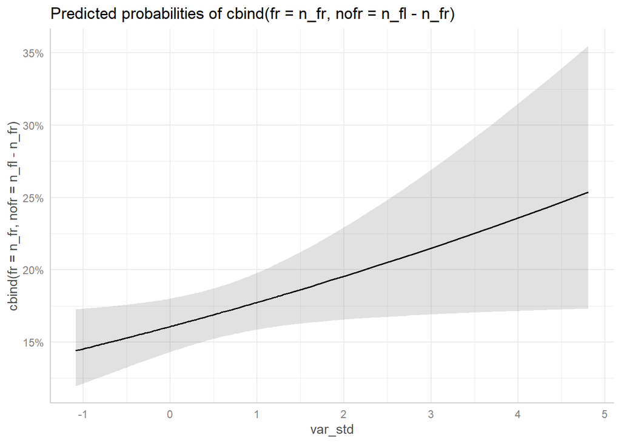

```r
plot(ggpredict(fr_init_linear_87,terms=c("var_std [all]")))
```

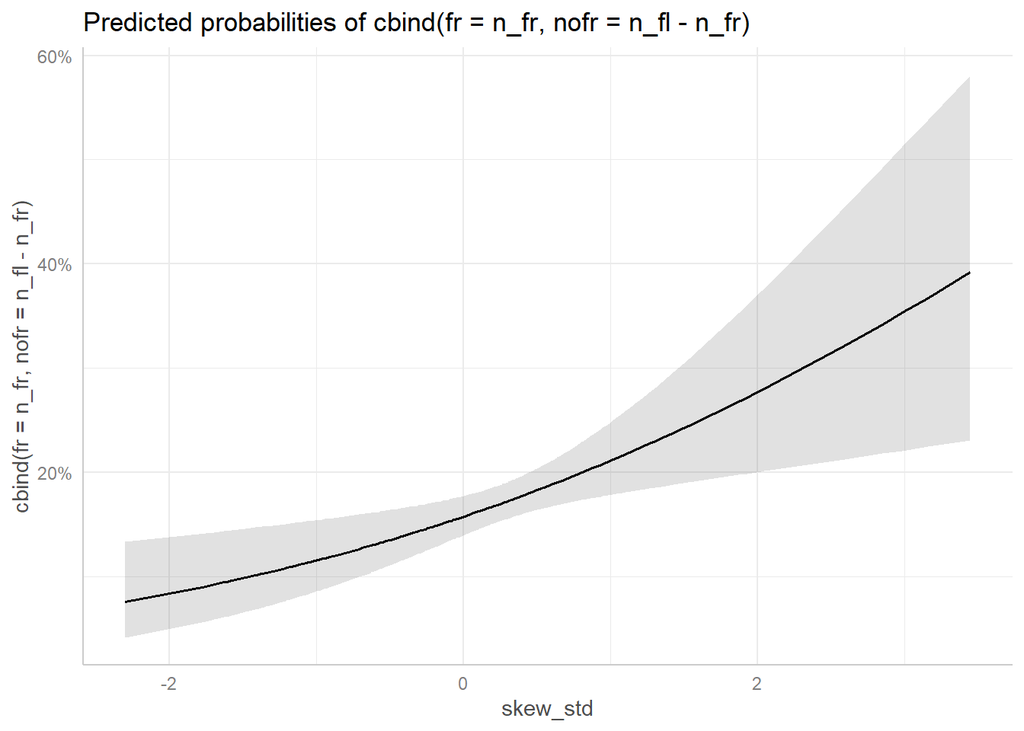

```r
plot(ggpredict(fr_init_linear_87,terms=c("skew_std [all]")))
```

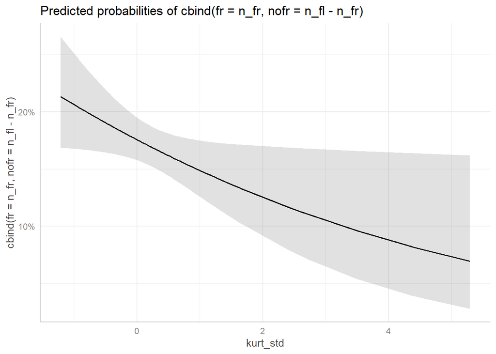

```r
plot(ggpredict(fr_init_linear_87,terms=c("kurt_std [all]")))
```

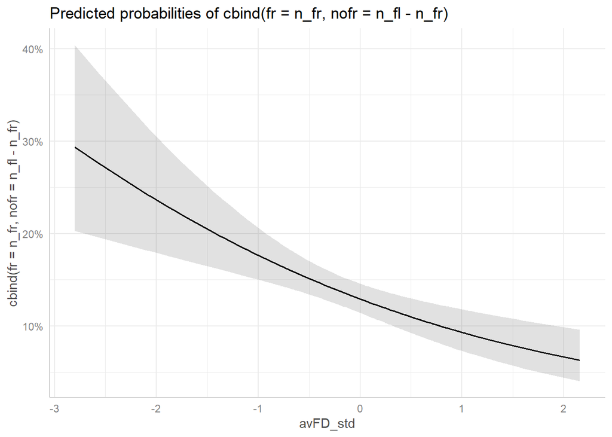

```r
plot(ggpredict(fr_init_linear_88,terms=c("avFD_std [all]")))
```

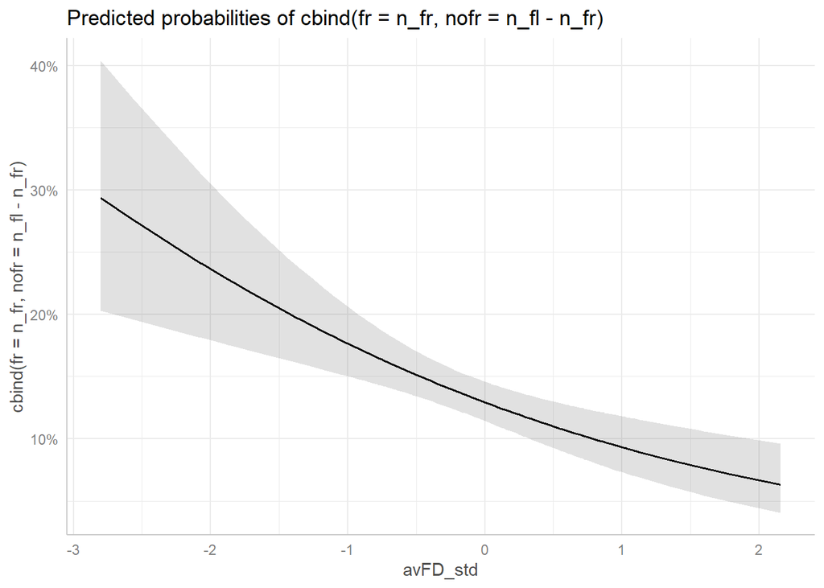

```r
plot(ggpredict(fr_init_linear_88,terms=c("avFD_std [all]")))
```

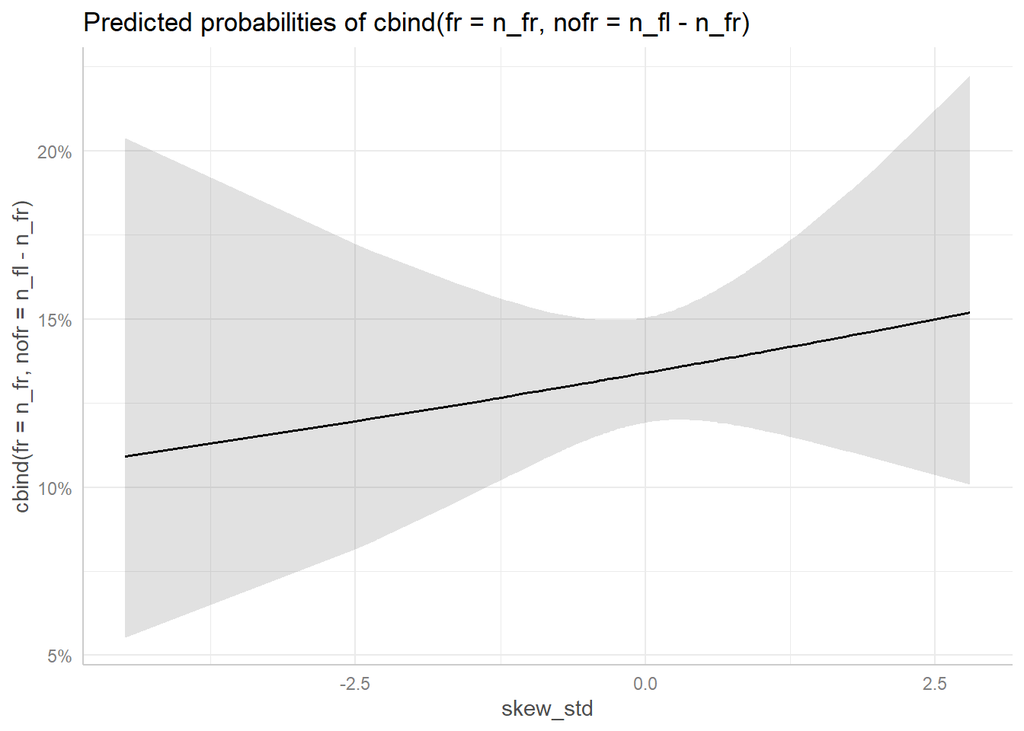

```r
plot(ggpredict(fr_init_linear_88,terms=c("skew_std [all]")))
```

#### Non-linear effects

```r
fr_init_nonlinear_87<-glm(cbind(fr=n_fr,nofr=n_fl-n_fr)~
                            avFD_std+var_std+skew_std+kurt_std+
                            I(avFD_std^2)+I(var_std^2)+
                            I(skew_std^2)+I(kurt_std^2),
                          subset(data_ids,year==1987),family="binomial")
fr_init_nonlinear_88<-glm(cbind(fr=n_fr,nofr=n_fl-n_fr)~
                            avFD_std+var_std+skew_std+kurt_std+
                            I(avFD_std^2)+I(var_std^2)+
                            I(skew_std^2)+I(kurt_std^2),
                    subset(data_ids,year==1988),family="binomial")
fr_init_nonlinear_89<-glm(cbind(fr=n_fr,nofr=n_fl-n_fr)~
                            avFD_std+var_std+skew_std+kurt_std+
                            I(avFD_std^2)+I(var_std^2)+
                            I(skew_std^2)+I(kurt_std^2),
                    subset(data_ids,year==1989),family="binomial")
tab_model(fr_init_nonlinear_87,fr_init_nonlinear_88,fr_init_nonlinear_89,
          transform=NULL,show.ci=F,show.se=T,show.stat=T,digits=3,
          dv.labels=c("1987","1988","1989"),
          title="Fruit initiation, nonlinear effects")
```

Fruit initiation, nonlinear effects

|  | 1987 |  |  |  | 1988 |  |  |  | 1989 |  |  |  |
| --- | --- | --- | --- | --- | --- | --- | --- | --- | --- | --- | --- | --- |
| Predictors | Log-Odds | std. Error | Statistic | p | Log-Odds | std. Error | Statistic | p | Log-Odds | std. Error | Statistic | p |
| (Intercept) | -1.711 | 0.112 | -15.256 | **<0.001** | -2.045 | 0.107 | -19.086 | **<0.001** | -1.943 | 0.114 | -17.017 | **<0.001** |
| avFD std | -0.040 | 0.096 | -0.417 | 0.677 | -0.298 | 0.107 | -2.783 | **0.005** | -0.331 | 0.132 | -2.517 | **0.012** |
| var std | 0.045 | 0.112 | 0.404 | 0.686 | -0.168 | 0.133 | -1.268 | 0.205 | 0.173 | 0.141 | 1.230 | 0.219 |
| skew std | 0.394 | 0.123 | 3.210 | **0.001** | 0.072 | 0.086 | 0.839 | 0.401 | 0.352 | 0.121 | 2.916 | **0.004** |
| kurt std | -0.351 | 0.154 | -2.284 | **0.022** | 0.016 | 0.128 | 0.122 | 0.903 | -0.039 | 0.188 | -0.209 | 0.834 |
| avFD std^2 | -0.083 | 0.075 | -1.117 | 0.264 | 0.095 | 0.082 | 1.160 | 0.246 | 0.054 | 0.090 | 0.607 | 0.544 |
| var std^2 | 0.028 | 0.030 | 0.931 | 0.352 | 0.113 | 0.053 | 2.132 | **0.033** | -0.046 | 0.059 | -0.781 | 0.435 |
| skew std^2 | 0.103 | 0.089 | 1.158 | 0.247 | 0.093 | 0.088 | 1.051 | 0.293 | 0.133 | 0.134 | 0.992 | 0.321 |
| kurt std^2 | 0.006 | 0.041 | 0.137 | 0.891 | -0.025 | 0.034 | -0.727 | 0.467 | -0.050 | 0.071 | -0.700 | 0.484 |
| Observations | 198 |  |  |  | 142 |  |  |  | 88 |  |  |  |

```r
Anova(fr_init_nonlinear_87)
```

|  | LR Chisq | Df | Pr(>Chisq) |
| --- | --- | --- | --- |
| avFD_std | 0.17471728 | 1 | 0.675952994 |
| var_std | 0.16312003 | 1 | 0.686300073 |
| skew_std | 10.40937097 | 1 | 0.001253774 |
| kurt_std | 5.29604747 | 1 | 0.021373872 |
| I(avFD_std^2) | 1.43208880 | 1 | 0.231423847 |
| I(var_std^2) | 0.85716196 | 1 | 0.354534116 |
| I(skew_std^2) | 1.32413993 | 1 | 0.249850412 |
| I(kurt_std^2) | 0.01877773 | 1 | 0.891005624 |

```r
Anova(fr_init_nonlinear_88)
```

|  | LR Chisq | Df | Pr(>Chisq) |
| --- | --- | --- | --- |
| avFD_std | 8.41410289 | 1 | 0.003723215 |
| var_std | 1.58995386 | 1 | 0.207332725 |
| skew_std | 0.70273321 | 1 | 0.401866818 |
| kurt_std | 0.01478839 | 1 | 0.903209849 |
| I(avFD_std^2) | 1.31166951 | 1 | 0.252092603 |
| I(var_std^2) | 4.33149660 | 1 | 0.037413336 |
| I(skew_std^2) | 1.07407434 | 1 | 0.300026960 |
| I(kurt_std^2) | 0.52703599 | 1 | 0.467855661 |

```r
Anova(fr_init_nonlinear_89)
```

|  | LR Chisq | Df | Pr(>Chisq) |
| --- | --- | --- | --- |
| avFD_std | 6.9587669 | 1 | 0.008340950 |
| var_std | 1.5398875 | 1 | 0.214634551 |
| skew_std | 8.5000457 | 1 | 0.003551376 |
| kurt_std | 0.0438316 | 1 | 0.834167240 |
| I(avFD_std^2) | 0.3603224 | 1 | 0.548327232 |
| I(var_std^2) | 0.6182011 | 1 | 0.431716549 |
| I(skew_std^2) | 0.9408120 | 1 | 0.332069103 |
| I(kurt_std^2) | 0.4767609 | 1 | 0.489893159 |

##### Plot predictions

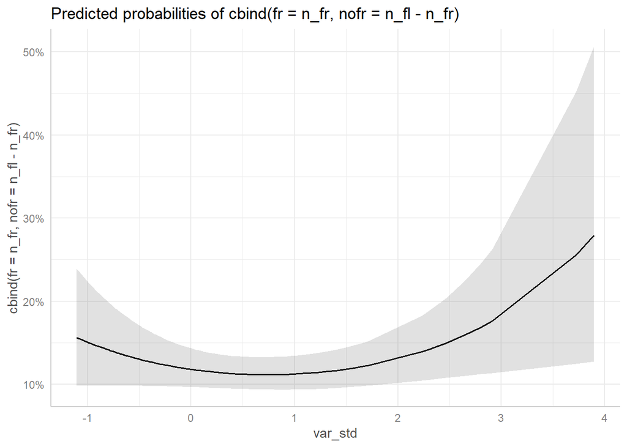

```r
plot(ggpredict(fr_init_nonlinear_88,terms=c("var_std [all]")))
```

## SEEDS ESCAPING PREDATION

Using (within-year) standardized traits.

### Global models

#### Linear effects

```r
seed_escpred_linear<-glm(cbind(npr_seeds=round(n_seed)-round(n_preyed_seed),
                        pr_seeds=round(n_preyed_seed))~
                          avFD_std+var_std+skew_std+kurt_std+year+
                          avFD_std:year+var_std:year+
                          skew_std:year+kurt_std:year,
                        data_ids,family="binomial")
tab_model(seed_escpred_linear,
          transform=NULL,show.ci=F,show.se=T,show.stat=T,digits=3,
          dv.labels=c("Seeds escaping predation, linear effects"))
```

|  | Seeds escaping predation, linear effects |  |  |  |
| --- | --- | --- | --- | --- |
| Predictors | Log-Odds | std. Error | Statistic | p |
| (Intercept) | 2.412 | 0.123 | 19.638 | **<0.001** |
| avFD std | 0.361 | 0.166 | 2.182 | **0.029** |
| var std | -0.201 | 0.079 | -2.550 | **0.011** |
| skew std | 0.734 | 0.180 | 4.073 | **<0.001** |
| kurt std | -0.278 | 0.132 | -2.102 | **0.036** |
| year 1988 | -2.222 | 0.138 | -16.115 | **<0.001** |
| year 1989 | -1.265 | 0.153 | -8.295 | **<0.001** |
| avFD std × year 1988 | -0.004 | 0.179 | -0.021 | 0.983 |
| avFD std × year 1989 | -0.439 | 0.188 | -2.342 | **0.019** |
| var std × year 1988 | -0.017 | 0.102 | -0.165 | 0.869 |
| var std × year 1989 | 0.015 | 0.115 | 0.135 | 0.893 |
| skew std × year 1988 | -0.474 | 0.192 | -2.470 | **0.014** |
| skew std × year 1989 | -0.164 | 0.207 | -0.792 | 0.429 |
| kurt std × year 1988 | 0.255 | 0.145 | 1.759 | 0.079 |
| kurt std × year 1989 | 0.385 | 0.169 | 2.280 | **0.023** |
| Observations | 299 |  |  |  |

```r
Anova(seed_escpred_linear)
```

|  | LR Chisq | Df | Pr(>Chisq) |
| --- | --- | --- | --- |
| avFD_std | 17.30952761 | 1 | 3.175905e-05 |
| var_std | 22.96094228 | 1 | 1.653265e-06 |
| skew_std | 54.67696342 | 1 | 1.420618e-13 |
| kurt_std | 0.36529290 | 1 | 5.455813e-01 |
| year | 586.03597475 | 2 | 5.545044e-128 |
| avFD_std:year | 16.24257347 | 2 | 2.971461e-04 |
| var_std:year | 0.09695379 | 2 | 9.526794e-01 |
| skew_std:year | 10.70165496 | 2 | 4.744224e-03 |
| kurt_std:year | 5.09826670 | 2 | 7.814936e-02 |

```r
check_collinearity(glm(cbind(npr_seeds=round(n_seed)-round(n_preyed_seed),
                        pr_seeds=round(n_preyed_seed))~
                          avFD_std+var_std+skew_std+kurt_std+year,
                        data_ids,family="binomial"))
```

| Term | VIF | VIF_CI_low | VIF_CI_high | SE_factor | Tolerance | Tolerance_CI_low | Tolerance_CI_high |
| --- | --- | --- | --- | --- | --- | --- | --- |
| avFD_std | 1.110595 | 1.032912 | 1.371636 | 1.053848 | 0.9004181 | 0.72905659 | 0.9681367 |
| var_std | 1.122781 | 1.040321 | 1.373880 | 1.059613 | 0.8906459 | 0.72786561 | 0.9612420 |
| skew_std | 1.174319 | 1.074565 | 1.407527 | 1.083660 | 0.8515571 | 0.71046612 | 0.9306091 |
| kurt_std | 1.017092 | 1.000022 | 14.098791 | 1.008510 | 0.9831954 | 0.07092807 | 0.9999777 |
| year | 1.060906 | 1.008065 | 1.459936 | 1.030003 | 0.9425906 | 0.68496137 | 0.9919992 |

According to Anova, differences among years in the effects of avFD and skew.

##### Plot predictions

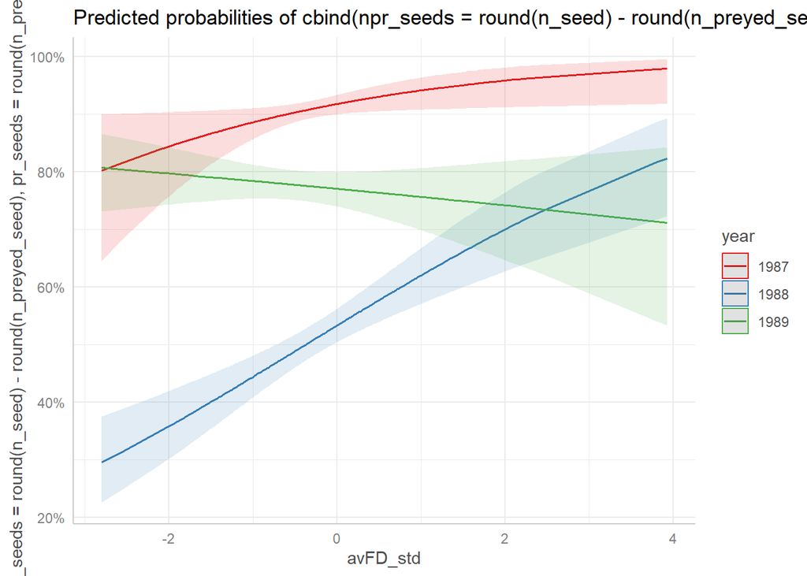

```r
plot(ggpredict(seed_escpred_linear,terms=c("avFD_std [all]","year")))
```

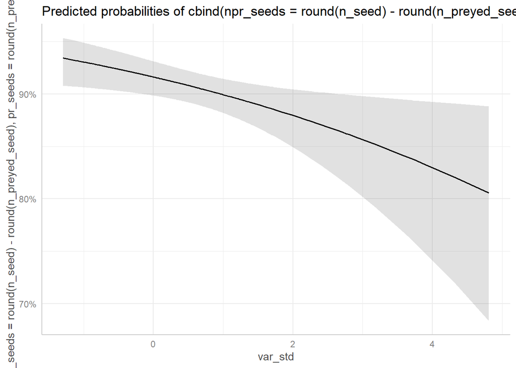

```r
# Significant diffs among years
plot(ggpredict(seed_escpred_linear,terms=c("var_std [all]")))
```

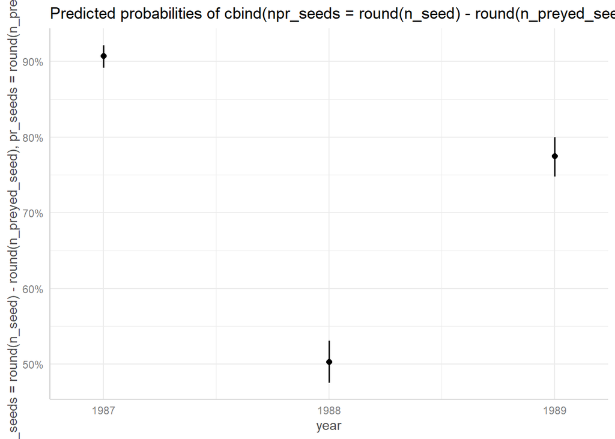

```r
# Main effect signficant
plot(ggpredict(seed_escpred_linear,terms=c("year [all]")))
```

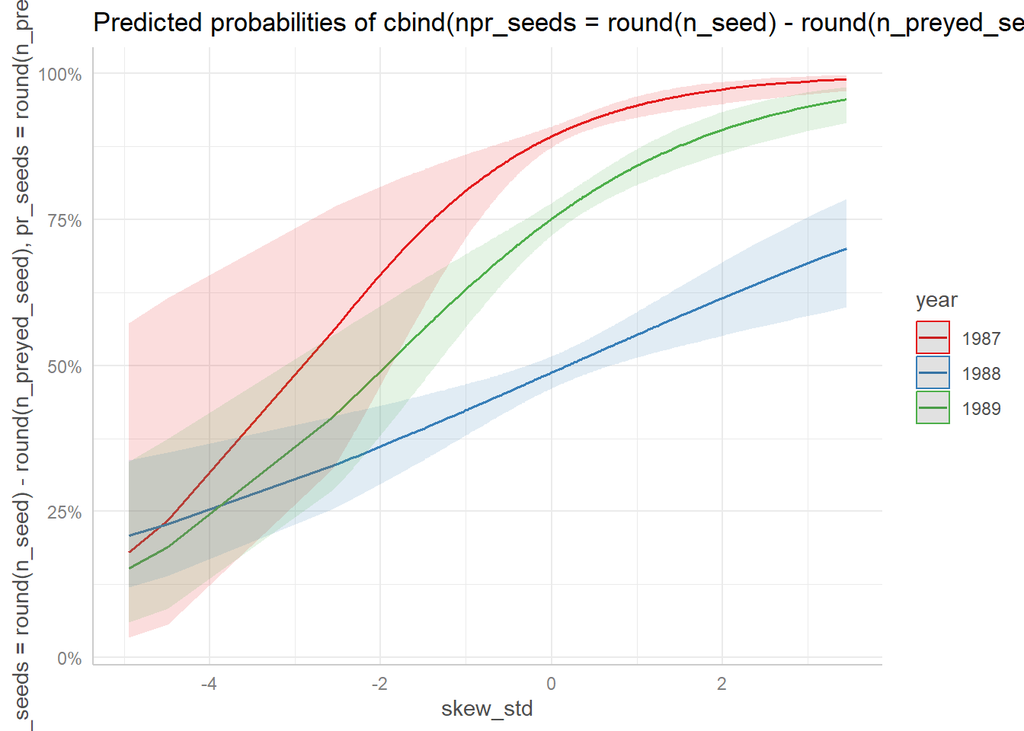

```r
# Main effect signficant
plot(ggpredict(seed_escpred_linear,terms=c("skew_std [all]","year")))
```

```r
# Significant diffs among years
```

#### Non-linear effects

```r
seed_escpred_nonlinear<-glm(cbind(npr_seeds=round(n_seed)-round(n_preyed_seed),
                        pr_seeds=round(n_preyed_seed))~
                          avFD_std+var_std+skew_std+kurt_std+year+
                          avFD_std:year+var_std:year+
                          skew_std:year+kurt_std:year+
                          I(avFD_std^2)+I(var_std^2)+
                          I(skew_std^2)+I(kurt_std^2)+
                          I(avFD_std^2):year+I(var_std^2):year+
                          I(skew_std^2):year+I(kurt_std^2):year,
                        data_ids,family="binomial")
tab_model(seed_escpred_nonlinear,
          transform=NULL,show.ci=F,show.se=T,show.stat=T,digits=3,
          dv.labels=c("Seeds escaping predation, non linear effects"))
```

|  | Seeds escaping predation, non linear effects |  |  |  |
| --- | --- | --- | --- | --- |
| Predictors | Log-Odds | std. Error | Statistic | p |
| (Intercept) | 2.088 | 0.193 | 10.819 | **<0.001** |
| avFD std | 0.231 | 0.159 | 1.454 | 0.146 |
| var std | -0.478 | 0.183 | -2.609 | **0.009** |
| skew std | 1.032 | 0.219 | 4.713 | **<0.001** |
| kurt std | -0.945 | 0.221 | -4.275 | **<0.001** |
| year 1988 | -2.097 | 0.212 | -9.898 | **<0.001** |
| year 1989 | -0.812 | 0.225 | -3.613 | **<0.001** |
| avFD std^2 | -0.183 | 0.169 | -1.082 | 0.279 |
| var std^2 | 0.085 | 0.046 | 1.875 | 0.061 |
| skew std^2 | 0.772 | 0.179 | 4.315 | **<0.001** |
| kurt std^2 | -0.101 | 0.077 | -1.307 | 0.191 |
| avFD std × year 1988 | 0.228 | 0.180 | 1.266 | 0.206 |
| avFD std × year 1989 | -0.495 | 0.203 | -2.436 | **0.015** |
| var std × year 1988 | 0.181 | 0.216 | 0.840 | 0.401 |
| var std × year 1989 | 0.124 | 0.239 | 0.519 | 0.604 |
| skew std × year 1988 | -0.722 | 0.231 | -3.121 | **0.002** |
| skew std × year 1989 | -0.613 | 0.256 | -2.398 | **0.017** |
| kurt std × year 1988 | 0.776 | 0.245 | 3.165 | **0.002** |
| kurt std × year 1989 | 1.309 | 0.294 | 4.449 | **<0.001** |
| year 1988 × avFD std^2 | 0.332 | 0.182 | 1.824 | 0.068 |
| year 1989 × avFD std^2 | -0.013 | 0.189 | -0.071 | 0.943 |
| year 1988 × var std^2 | -0.008 | 0.066 | -0.118 | 0.906 |
| year 1989 × var std^2 | 0.006 | 0.083 | 0.078 | 0.938 |
| year 1988 × skew std^2 | -0.659 | 0.194 | -3.399 | **0.001** |
| year 1989 × skew std^2 | -0.796 | 0.224 | -3.557 | **<0.001** |
| year 1988 × kurt std^2 | 0.096 | 0.082 | 1.176 | 0.240 |
| year 1989 × kurt std^2 | 0.027 | 0.102 | 0.265 | 0.791 |
| Observations | 299 |  |  |  |

```r
Anova(seed_escpred_nonlinear) # Use type II (now) or III?
```

|  | LR Chisq | Df | Pr(>Chisq) |
| --- | --- | --- | --- |
| avFD_std | 1.574819e+01 | 1 | 7.235700e-05 |
| var_std | 1.845202e+01 | 1 | 1.742356e-05 |
| skew_std | 4.176640e+01 | 1 | 1.028556e-10 |
| kurt_std | 4.747549e+00 | 1 | 2.934005e-02 |
| year | 5.556524e+02 | 2 | 2.195931e-121 |
| I(avFD_std^2) | 4.839978e-03 | 1 | 9.445360e-01 |
| I(var_std^2) | 8.273930e+00 | 1 | 4.021836e-03 |
| I(skew_std^2) | 9.312634e+00 | 1 | 2.275791e-03 |
| I(kurt_std^2) | 8.746856e-01 | 1 | 3.496614e-01 |
| avFD_std:year | 2.181037e+01 | 2 | 1.836276e-05 |

[output cut: 7 more lines]

Significant non-linear effects according to Anova: I(var_std^2), I(skew_std^2), year:I(avFD_std^2), year:I(skew_std^2)

##### Plot predictions

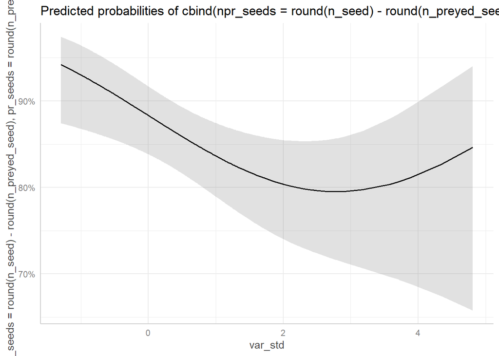

```r
plot(ggpredict(seed_escpred_nonlinear,terms=c("var_std [all]")))
```

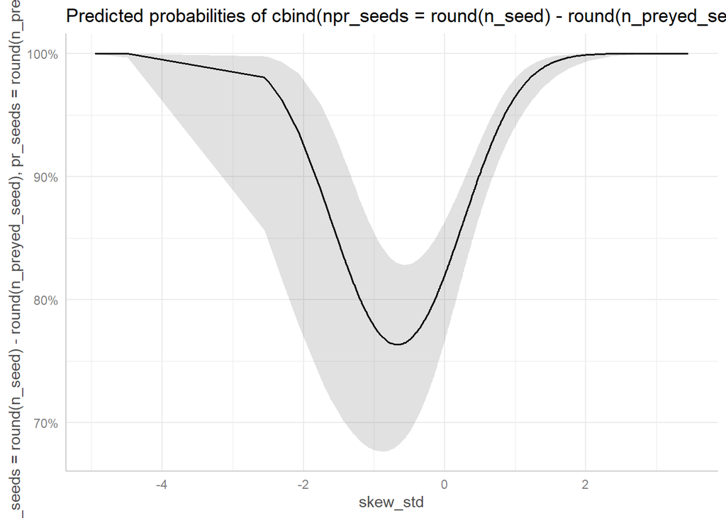

```r
# Quadratic effect
plot(ggpredict(seed_escpred_nonlinear,terms=c("skew_std [all]")))
```

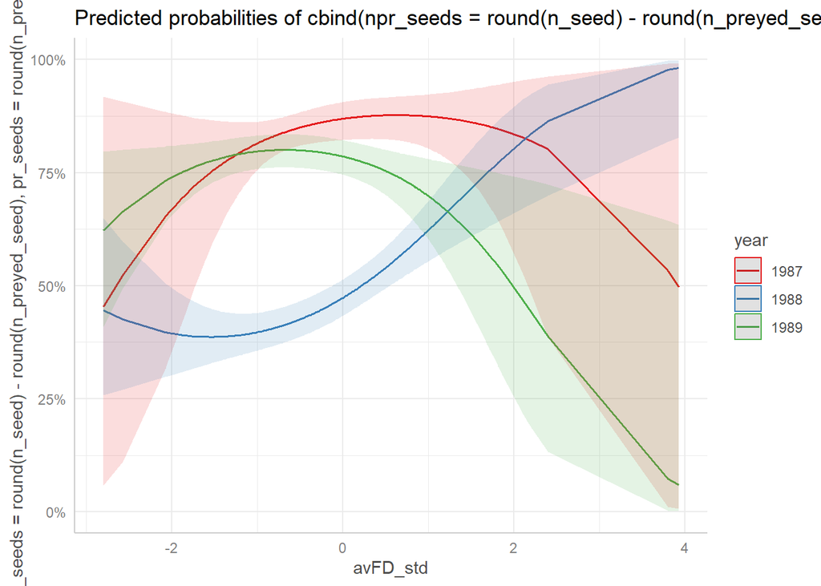

```r
# Quadratic effect
plot(ggpredict(seed_escpred_nonlinear,terms=c("avFD_std [all]","year")))
```

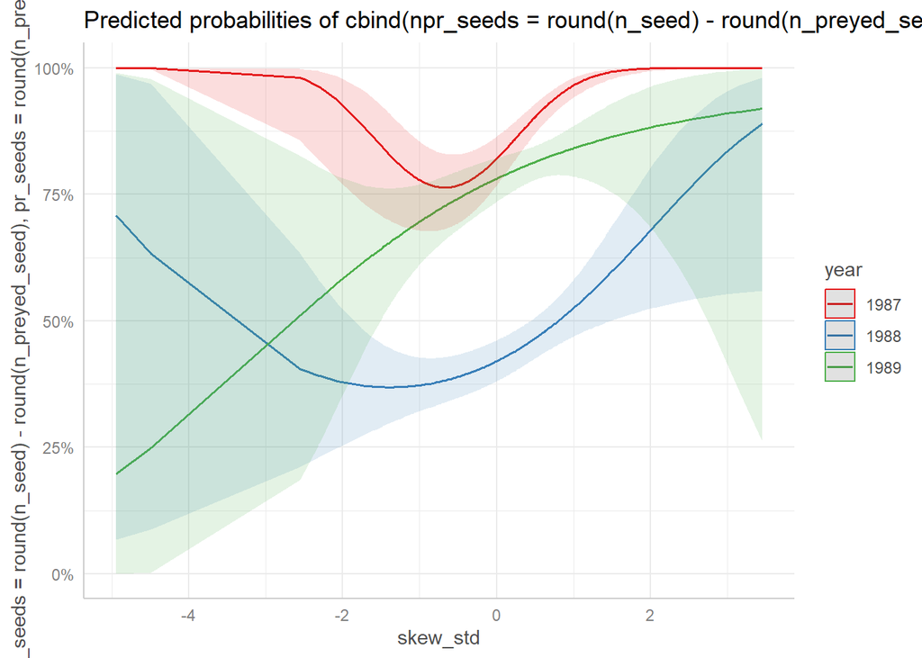

```r
# Quadratic effect, differences among years
plot(ggpredict(seed_escpred_nonlinear,terms=c("skew_std [all]","year")))
```

```r
# Quadratic effect, differences among years
```

### Yearly models

#### Linear effects

```r
seed_escpred_linear_87<-glm(cbind(npr_seeds=round(n_seed)-round(n_preyed_seed),
                                  pr_seeds=round(n_preyed_seed))~
                              avFD_std+var_std+skew_std+kurt_std,
                            subset(data_ids,year==1987),family="binomial")
seed_escpred_linear_88<-glm(cbind(npr_seeds=round(n_seed)-round(n_preyed_seed),
                                  pr_seeds=round(n_preyed_seed))~
                              avFD_std+var_std+skew_std+kurt_std,
                            subset(data_ids,year==1988),family="binomial")
seed_escpred_linear_89<-glm(cbind(npr_seeds=round(n_seed)-round(n_preyed_seed),
                                  pr_seeds=round(n_preyed_seed))~
                              avFD_std+var_std+skew_std+kurt_std,
                            subset(data_ids,year==1989),family="binomial")
tab_model(seed_escpred_linear_87,seed_escpred_linear_88,seed_escpred_linear_89,
          transform=NULL,show.ci=F,show.se=T,show.stat=T,digits=3,
          dv.labels=c("1987","1988","1989"),
          title="Seeds escaping predation, linear effects")
```

Seeds escaping predation, linear effects

|  | 1987 |  |  |  | 1988 |  |  |  | 1989 |  |  |  |
| --- | --- | --- | --- | --- | --- | --- | --- | --- | --- | --- | --- | --- |
| Predictors | Log-Odds | std. Error | Statistic | p | Log-Odds | std. Error | Statistic | p | Log-Odds | std. Error | Statistic | p |
| (Intercept) | 2.412 | 0.123 | 19.638 | **<0.001** | 0.190 | 0.063 | 3.043 | **0.002** | 1.147 | 0.090 | 12.684 | **<0.001** |
| avFD std | 0.361 | 0.166 | 2.182 | **0.029** | 0.358 | 0.069 | 5.179 | **<0.001** | -0.078 | 0.088 | -0.886 | 0.376 |
| var std | -0.201 | 0.079 | -2.550 | **0.011** | -0.218 | 0.065 | -3.377 | **0.001** | -0.186 | 0.083 | -2.238 | **0.025** |
| skew std | 0.734 | 0.180 | 4.073 | **<0.001** | 0.260 | 0.066 | 3.949 | **<0.001** | 0.570 | 0.103 | 5.546 | **<0.001** |
| kurt std | -0.278 | 0.132 | -2.102 | **0.036** | -0.022 | 0.060 | -0.370 | 0.711 | 0.108 | 0.105 | 1.022 | 0.307 |
| Observations | 131 |  |  |  | 103 |  |  |  | 65 |  |  |  |

```r
check_collinearity(seed_escpred_linear_87)
```

| Term | VIF | VIF_CI_low | VIF_CI_high | SE_factor | Tolerance | Tolerance_CI_low | Tolerance_CI_high |
| --- | --- | --- | --- | --- | --- | --- | --- |
| avFD_std | 1.758675 | 1.443850 | 2.296807 | 1.326151 | 0.5686098 | 0.4353871 | 0.6925926 |
| var_std | 1.414418 | 1.203138 | 1.845447 | 1.189293 | 0.7070044 | 0.5418742 | 0.8311597 |
| skew_std | 3.804523 | 2.916489 | 5.104041 | 1.950519 | 0.2628450 | 0.1959232 | 0.3428780 |
| kurt_std | 2.501220 | 1.975823 | 3.309498 | 1.581524 | 0.3998050 | 0.3021606 | 0.5061183 |

```r
check_collinearity(seed_escpred_linear_88)
```

| Term | VIF | VIF_CI_low | VIF_CI_high | SE_factor | Tolerance | Tolerance_CI_low | Tolerance_CI_high |
| --- | --- | --- | --- | --- | --- | --- | --- |
| avFD_std | 1.138432 | 1.026487 | 1.723489 | 1.066973 | 0.8784014 | 0.58021830 | 0.9741961 |
| var_std | 1.114461 | 1.016698 | 1.784597 | 1.055681 | 0.8972944 | 0.56035045 | 0.9835760 |
| skew_std | 1.273074 | 1.098950 | 1.753607 | 1.128306 | 0.7855002 | 0.57025316 | 0.9099594 |
| kurt_std | 1.027859 | 1.000031 | 25.863935 | 1.013834 | 0.9728956 | 0.03866388 | 0.9999688 |

```r
check_collinearity(seed_escpred_linear_89)
```

| Term | VIF | VIF_CI_low | VIF_CI_high | SE_factor | Tolerance | Tolerance_CI_low | Tolerance_CI_high |
| --- | --- | --- | --- | --- | --- | --- | --- |
| avFD_std | 1.126700 | 1.014989 | 2.070973 | 1.061461 | 0.8875474 | 0.4828648837 | 0.9852322 |
| var_std | 1.243617 | 1.065260 | 1.909421 | 1.115176 | 0.8041062 | 0.5237188985 | 0.9387376 |
| skew_std | 1.155747 | 1.025313 | 1.958271 | 1.075057 | 0.8652415 | 0.5106545448 | 0.9753116 |
| kurt_std | 1.018023 | 1.000000 | 4391.356129 | 1.008971 | 0.9822961 | 0.0002277201 | 0.9999999 |

```r
Anova(seed_escpred_linear_87)
```

|  | LR Chisq | Df | Pr(>Chisq) |
| --- | --- | --- | --- |
| avFD_std | 5.184809 | 1 | 2.278517e-02 |
| var_std | 6.422798 | 1 | 1.126645e-02 |
| skew_std | 17.118704 | 1 | 3.511479e-05 |
| kurt_std | 4.310482 | 1 | 3.787823e-02 |

```r
Anova(seed_escpred_linear_88)
```

|  | LR Chisq | Df | Pr(>Chisq) |
| --- | --- | --- | --- |
| avFD_std | 27.580545 | 1 | 1.506868e-07 |
| var_std | 11.646632 | 1 | 6.431888e-04 |
| skew_std | 15.920130 | 1 | 6.607225e-05 |
| kurt_std | 0.137812 | 1 | 7.104659e-01 |

```r
Anova(seed_escpred_linear_89)
```

|  | LR Chisq | Df | Pr(>Chisq) |
| --- | --- | --- | --- |
| avFD_std | 0.7867474 | 1 | 3.750855e-01 |
| var_std | 4.9884666 | 1 | 2.551681e-02 |
| skew_std | 32.3397846 | 1 | 1.294359e-08 |
| kurt_std | 1.0152656 | 1 | 3.136446e-01 |

##### Plot predictions

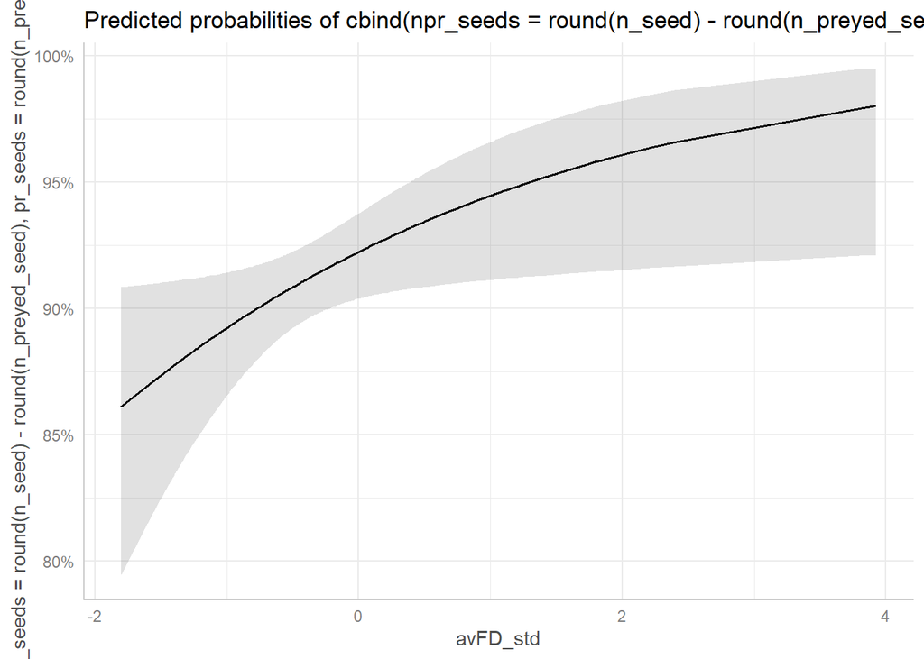

```r
plot(ggpredict(seed_escpred_linear_87,terms=c("avFD_std [all]")))
```

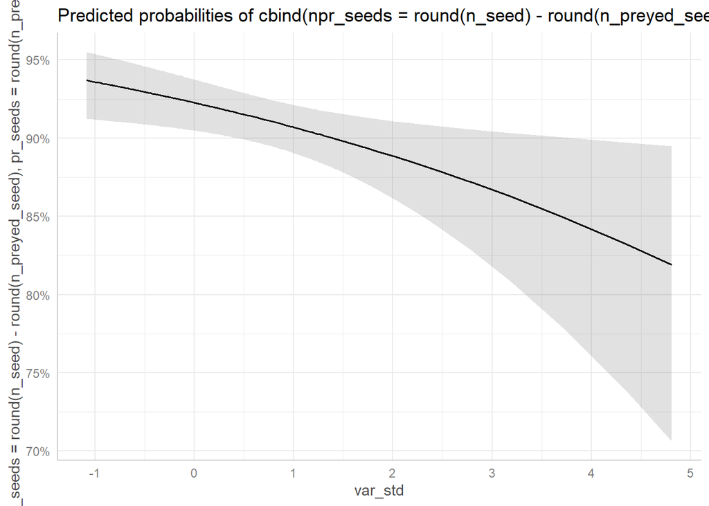

```r
plot(ggpredict(seed_escpred_linear_87,terms=c("var_std [all]")))
```

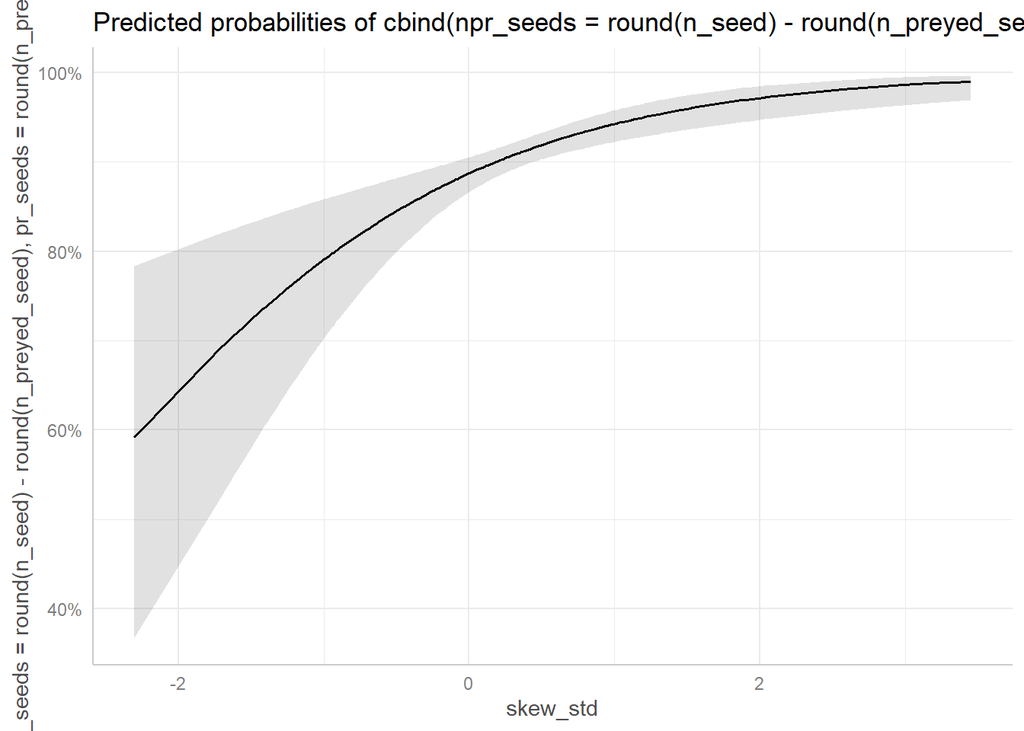

```r
plot(ggpredict(seed_escpred_linear_87,terms=c("skew_std [all]")))
```

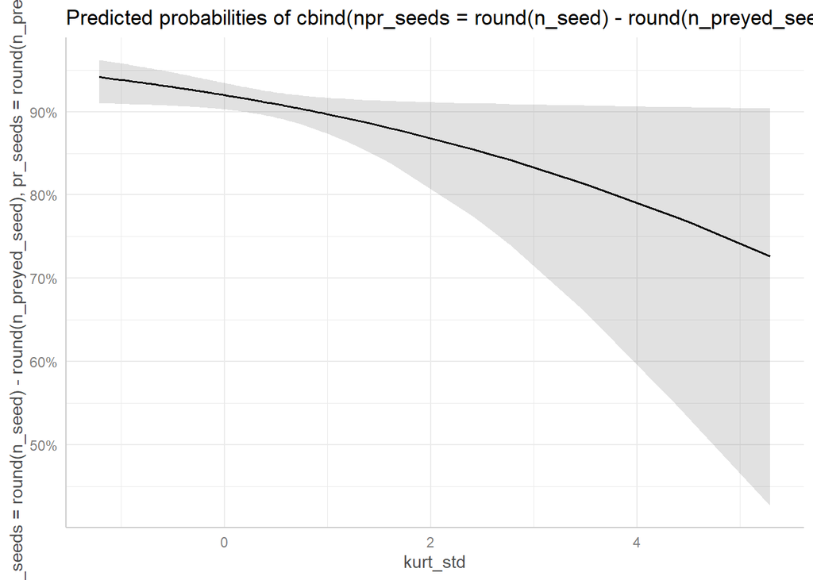

```r
plot(ggpredict(seed_escpred_linear_87,terms=c("kurt_std [all]")))
```

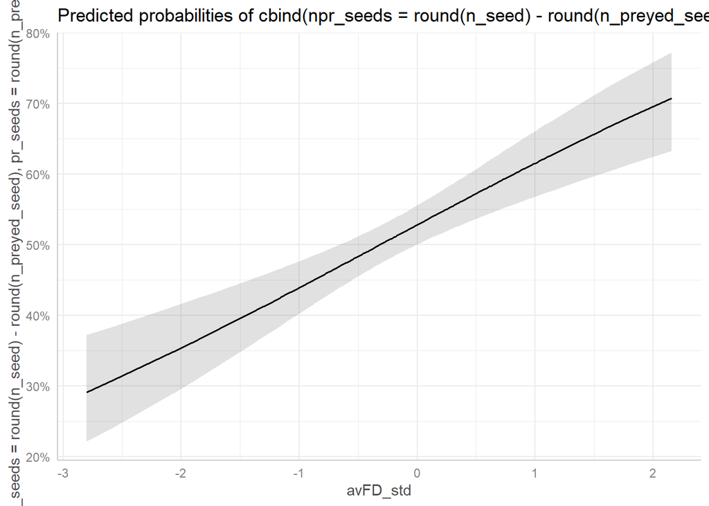

```r
plot(ggpredict(seed_escpred_linear_88,terms=c("avFD_std [all]")))
```

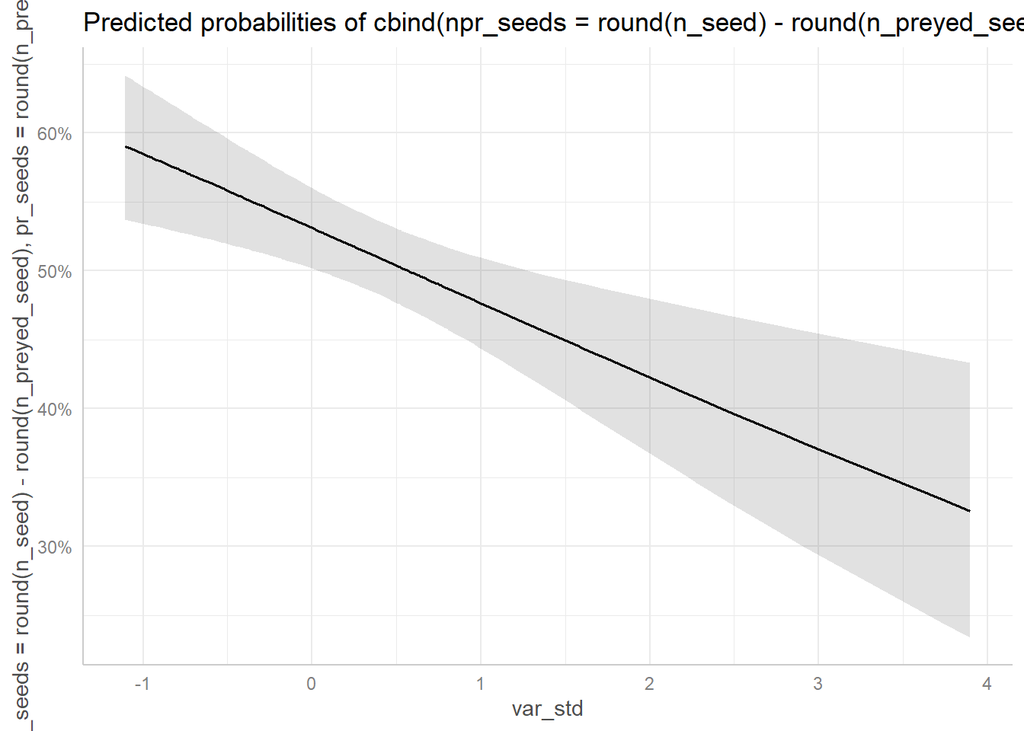

```r
plot(ggpredict(seed_escpred_linear_88,terms=c("var_std [all]")))
```

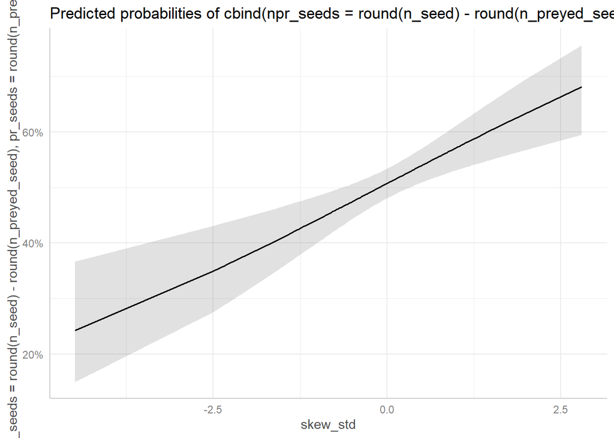

```r
plot(ggpredict(seed_escpred_linear_88,terms=c("skew_std [all]")))
```

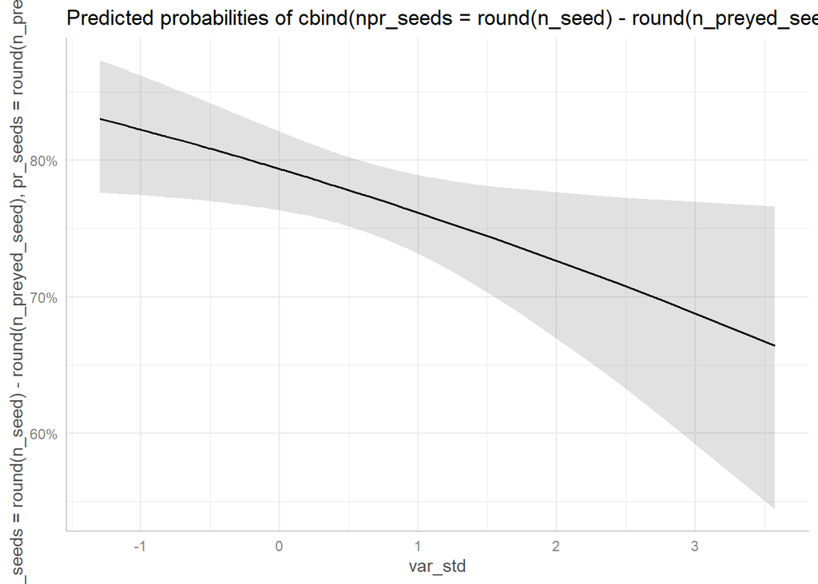

```r
plot(ggpredict(seed_escpred_linear_89,terms=c("var_std [all]")))
```

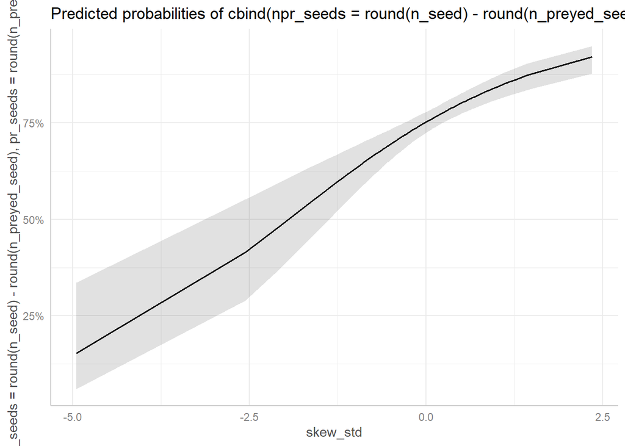

```r
plot(ggpredict(seed_escpred_linear_89,terms=c("skew_std [all]")))
```

#### Non-linear effects

```r
seed_escpred_nonlinear_87<-glm(cbind(npr_seeds=round(n_seed)-
                                       round(n_preyed_seed),
                                     pr_seeds=round(n_preyed_seed))~
                                 avFD_std+var_std+skew_std+kurt_std+
                                 I(avFD_std^2)+I(var_std^2)+
                                 I(skew_std^2)+I(kurt_std^2),
                               subset(data_ids,year==1987),family="binomial")
seed_escpred_nonlinear_88<-glm(cbind(npr_seeds=round(n_seed)-
                                       round(n_preyed_seed),
                                     pr_seeds=round(n_preyed_seed))~
                                 avFD_std+var_std+skew_std+kurt_std+
                                 I(avFD_std^2)+I(var_std^2)+
                                 I(skew_std^2)+I(kurt_std^2),
                               subset(data_ids,year==1988),family="binomial")
seed_escpred_nonlinear_89<-glm(cbind(npr_seeds=round(n_seed)-
                                       round(n_preyed_seed),
                                     pr_seeds=round(n_preyed_seed))~
                                 avFD_std+var_std+skew_std+kurt_std+
                                 I(avFD_std^2)+I(var_std^2)+
                                 I(skew_std^2)+I(kurt_std^2),
                               subset(data_ids,year==1989),family="binomial")
# nobs(seed_escpred_nonlinear_89)/
# dim(model.matrix(seed_escpred_nonlinear_89))[2] = 7.2
# Careful! Only case when this ratio is <10
tab_model(seed_escpred_nonlinear_87,seed_escpred_nonlinear_88,
          seed_escpred_nonlinear_89,
          transform=NULL,show.ci=F,show.se=T,show.stat=T,digits=3,
          dv.labels=c("1987","1988","1989"),
          title="Seeds escaping predation, nonlinear effects")
```

Seeds escaping predation, nonlinear effects

|  | 1987 |  |  |  | 1988 |  |  |  | 1989 |  |  |  |
| --- | --- | --- | --- | --- | --- | --- | --- | --- | --- | --- | --- | --- |
| Predictors | Log-Odds | std. Error | Statistic | p | Log-Odds | std. Error | Statistic | p | Log-Odds | std. Error | Statistic | p |
| (Intercept) | 2.088 | 0.193 | 10.819 | **<0.001** | -0.009 | 0.087 | -0.103 | 0.918 | 1.276 | 0.115 | 11.080 | **<0.001** |
| avFD std | 0.231 | 0.159 | 1.454 | 0.146 | 0.459 | 0.085 | 5.401 | **<0.001** | -0.264 | 0.126 | -2.085 | **0.037** |
| var std | -0.478 | 0.183 | -2.609 | **0.009** | -0.296 | 0.115 | -2.577 | **0.010** | -0.354 | 0.154 | -2.300 | **0.021** |
| skew std | 1.032 | 0.219 | 4.713 | **<0.001** | 0.310 | 0.075 | 4.157 | **<0.001** | 0.419 | 0.132 | 3.182 | **0.001** |
| kurt std | -0.945 | 0.221 | -4.275 | **<0.001** | -0.169 | 0.106 | -1.586 | 0.113 | 0.365 | 0.194 | 1.877 | 0.061 |
| avFD std^2 | -0.183 | 0.169 | -1.082 | 0.279 | 0.150 | 0.068 | 2.189 | **0.029** | -0.196 | 0.086 | -2.287 | **0.022** |
| var std^2 | 0.085 | 0.046 | 1.875 | 0.061 | 0.078 | 0.047 | 1.641 | 0.101 | 0.092 | 0.069 | 1.336 | 0.182 |
| skew std^2 | 0.772 | 0.179 | 4.315 | **<0.001** | 0.112 | 0.075 | 1.490 | 0.136 | -0.024 | 0.135 | -0.181 | 0.857 |
| kurt std^2 | -0.101 | 0.077 | -1.307 | 0.191 | -0.005 | 0.027 | -0.168 | 0.866 | -0.074 | 0.067 | -1.101 | 0.271 |
| Observations | 131 |  |  |  | 103 |  |  |  | 65 |  |  |  |

```r
Anova(seed_escpred_nonlinear_87)
```

|  | LR Chisq | Df | Pr(>Chisq) |
| --- | --- | --- | --- |
| avFD_std | 2.211721 | 1 | 1.369658e-01 |
| var_std | 6.992712 | 1 | 8.184226e-03 |
| skew_std | 23.643838 | 1 | 1.159165e-06 |
| kurt_std | 18.829306 | 1 | 1.429537e-05 |
| I(avFD_std^2) | 1.137020 | 1 | 2.862830e-01 |
| I(var_std^2) | 3.794185 | 1 | 5.143091e-02 |
| I(skew_std^2) | 22.898216 | 1 | 1.708103e-06 |
| I(kurt_std^2) | 1.594896 | 1 | 2.066281e-01 |

```r
Anova(seed_escpred_nonlinear_88)
```

|  | LR Chisq | Df | Pr(>Chisq) |
| --- | --- | --- | --- |
| avFD_std | 31.10515201 | 1 | 2.444218e-08 |
| var_std | 6.67753490 | 1 | 9.763556e-03 |
| skew_std | 17.71211671 | 1 | 2.569845e-05 |
| kurt_std | 2.51696560 | 1 | 1.126271e-01 |
| I(avFD_std^2) | 4.90729820 | 1 | 2.674344e-02 |
| I(var_std^2) | 2.68821593 | 1 | 1.010929e-01 |
| I(skew_std^2) | 2.24822592 | 1 | 1.337677e-01 |
| I(kurt_std^2) | 0.02829281 | 1 | 8.664223e-01 |

```r
Anova(seed_escpred_nonlinear_89)
```

|  | LR Chisq | Df | Pr(>Chisq) |
| --- | --- | --- | --- |
| avFD_std | 4.24169298 | 1 | 0.039442817 |
| var_std | 5.49144353 | 1 | 0.019109759 |
| skew_std | 10.58081846 | 1 | 0.001142671 |
| kurt_std | 3.51093233 | 1 | 0.060965139 |
| I(avFD_std^2) | 5.10550419 | 1 | 0.023850046 |
| I(var_std^2) | 1.82346162 | 1 | 0.176901782 |
| I(skew_std^2) | 0.03260357 | 1 | 0.856709353 |
| I(kurt_std^2) | 1.26140788 | 1 | 0.261384766 |